# Weekly squad report

Weekly squad report Week ending Wednesday 14 October 2020 · Team B

10 Players trained

23,130 AU Squad load this week down 31% on last week

0.88 Average ACWR Safe range 0.8–1.5

0 Speak to first plus 3 to monitor

91% Wellness reporting 0 players sent none

**This week:** squad load was down 31% on last week. **0** players have both a load and a wellness flag and should be spoken to first; **3** more need monitoring.

## Players to review

Sorted by priority. “Speak to first” means load outside the safe range *and* wellness more than 0.5 SD below the player’s normal.

| Player | Team | Weekly load | vs last week | ACWR | Wellness (7d) | Status | Why flagged |
| --- | --- | --- | --- | --- | --- | --- | --- |
| B-2f23 | Team B | 2,060 | −47% | 0.69 | −0.19 | Monitor | ACWR below 0.8 |
| B-4405 | Team B | 1,350 | −45% | 0.67 | −0.46 | Monitor | ACWR below 0.8 |
| B-70b7 | Team B | 690 | −80% | 0.33 | −0.07 | Monitor | ACWR below 0.8 |

## Load vs wellness

Each dot is a player. Shaded areas are outside the safe range.

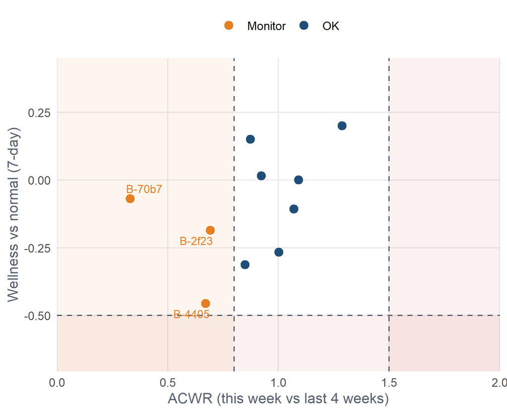

## Squad load, last 8 weeks

Total weekly load by team. This week is highlighted.

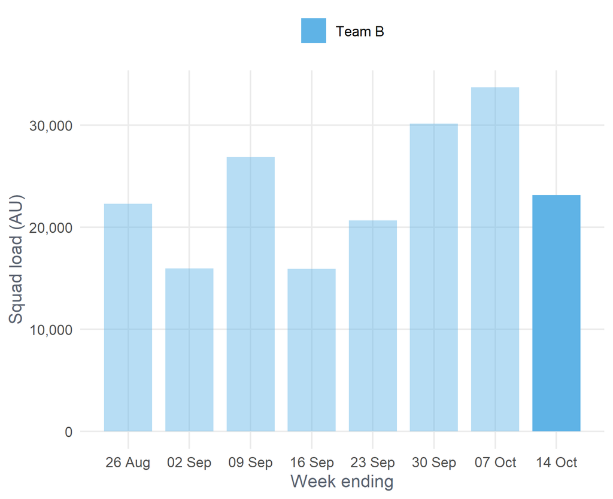

## Last four weeks for flagged players

Daily training load. The week under review is shaded.

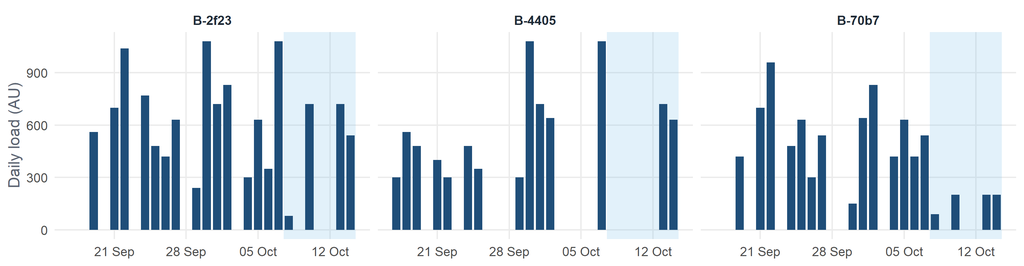

## Wellness reporting

91% of possible reports were completed this week. Players who sent none: **none, everyone reported**.

**NoteFull squad this week (click to expand)**

| Player | Team | Weekly load | ACWR | Monotony | Wellness (7d) | Reports | Status |
| --- | --- | --- | --- | --- | --- | --- | --- |
| B-48bf | Team B | 3,880 | 1.29 | 1.44 | 0.20 | 5 | OK |
| B-ab5e | Team B | 2,770 | 1.09 | 1.20 | 0.00 | 7 | OK |
| B-7895 | Team B | 2,720 | 1.07 | 1.40 | −0.11 | 7 | OK |
| B-e432 | Team B | 2,160 | 1.00 | 1.09 | −0.27 | 7 | OK |
| B-29c5 | Team B | 2,410 | 0.92 | 1.01 | 0.02 | 7 | OK |
| B-afc1 | Team B | 2,750 | 0.87 | 0.97 | 0.15 | 7 | OK |
| B-ab69 | Team B | 2,340 | 0.85 | 1.26 | −0.31 | 5 | OK |
| B-2f23 | Team B | 2,060 | 0.69 | 0.91 | −0.19 | 6 | Monitor |
| B-4405 | Team B | 1,350 | 0.67 | 0.63 | −0.46 | 6 | Monitor |
| B-70b7 | Team B | 690 | 0.33 | 1.06 | −0.07 | 7 | Monitor |

**How flags work:** ACWR = acute (7-day) ÷ chronic (28-day) load, with the safe range taken as 0.8–1.5. Wellness (7d) = average of fatigue, soreness, sleep quality and stress z-scores over the week, where 0 is the player’s own normal. Monotony = mean ÷ SD of daily load over the week. Flags prompt a conversation; they are not a diagnosis.  
Data: SoccerMon (Midoglu et al., CC BY 4.0). Report generated 11 November 2026 with R and Quarto by Will Page.